# Examen Computación Estadística con R

# Instrucciones

Cargue las bases de datos `kardex.csv` y `inventario.csv` junto con las librerías `tidyverse`, `DT`, `kableExtra`. A continuación responda los problemas 1 y 2 generando un reporte en Rmarkdown adecuado.

```r
# Cargamos librerías #
library(tidyverse)
library(DT)
library(kableExtra)
```

```r
# Cargamos bases de datos #

inventario <- read_delim("G:/Mi unidad/Universidad/Cursos/Computación Estadística con R/Prueba/inventario2.csv",
                         ";", escape_double = FALSE, trim_ws = TRUE)

kardex <- kardex <- read_delim("G:/Mi unidad/Universidad/Cursos/Computación Estadística con R/Prueba/kardex.csv",
                               ";", escape_double = FALSE, trim_ws = TRUE)
```

# Problema 1

1. Genere una nueva base de datos, con nombre `kardex_ampliada`, utilizando como links las columnas `cod_prod`, `cod_sucursal` y `fecha`. Además, muestre una visualización de la base de datos resultante utilizando `datatable()`.
2. Estudie la función `tally()`y utilícela para reportar un párrafo con las `linea` con más y menos elementos. Agregue, además, dos imágenes que contengan un producto de cada línea encontrada antes.
3. La sucursal de Parque Arauco requiere que usted le entregue una tabla que contenga la siguiente información:
   - La variable `depto` de la base de datos generada en (1).
   - $Q_{kardex}$: El número de productos del departamento tales que la diferencia entre `disponible` y `unidad_on_hand_disponible` es igual a 0.
   - $Q_{depto}$ corresponde al número de productos del departamento.
   - Un indicador de quiebre de productos para cada departamento. Este indicador esta definido como
     $$K_{depto} = 100\cdot\frac{Q_{kardex}}{Q_{depto}}.$$

   Muestre una visualización de la base de datos resultante utilizando `kable()` y comente lo que observa.

**Hint:** Genere una variable binaria que determine que productos cumplen con la condición de $Q_{kardex}$.

## Solución

1. El siguiente código realiza lo pedido

   ```r
   kardex %>%
     inner_join(inventario, by = c("cod_producto", "cod_sucursal", "fecha")) -> kardex_ampliada
   datatable(kardex_ampliada, filter = "top", fillContainer = TRUE, style = "bootstrap")
   ```

   |  | fecha | cod_sucursal | cod_producto | disponible | segunda | remate | cod_depto | cod_linea | cod_sub_linea | cod_modelo | cod_marca | cod_proveedor | cod_temporada | sucursal | depto | linea | sub_linea | modelo | producto | marca | proveedor | procedencia | fec_ult_rec | unidad_on_hand | unidad_on_hand_disponible | unidad_on_order | unidad_en_transito | costo_on_hand | costo_vigente_on_hand | … |
   | --- | --- | --- | --- | --- | --- | --- | --- | --- | --- | --- | --- | --- | --- | --- | --- | --- | --- | --- | --- | --- | --- | --- | --- | --- | --- | --- | --- | --- | --- | --- |
   | 1 | 2019-07-28T00:00:00Z | 10037 | 36992885 | 4 | 0 | 0 | D200 | 500762 | S502728 | 36992885 | 7901 | 96692040 | TTEMP | Marina Arauco | CUIDADO PERSONAL | MAQS AFEITAR Y CORTADORES DE PELO | CORTADORES DE PELO | CORTA PELO SIEGEN SG-8610 | CORTA PELO SIEGEN SG-8610 | SIEGEN | COMERCIALIZADORA LOS ROBLES LTDA | NAC | 2019-07-12T00:00:00Z | 5 | 5 | 0 | 0 | 105850 | 174950 | … |
   | 2 | 2019-07-28T00:00:00Z | 10029 | 36992885 | 0 | 0 | 0 | D200 | 500762 | S502728 | 36992885 | 7901 | 96692040 | TTEMP | Alto las Condes | CUIDADO PERSONAL | MAQS AFEITAR Y CORTADORES DE PELO | CORTADORES DE PELO | CORTA PELO SIEGEN SG-8610 | CORTA PELO SIEGEN SG-8610 | SIEGEN | COMERCIALIZADORA LOS ROBLES LTDA | NAC | 2019-07-12T00:00:00Z | 2 | 2 | 0 | 0 | 42340 | 69980 | … |
   | 3 | 2019-07-28T00:00:00Z | 10012 | 36992885 | 2 | 0 | 0 | D200 | 500762 | S502728 | 36992885 | 7901 | 96692040 | TTEMP | Parque Arauco | CUIDADO PERSONAL | MAQS AFEITAR Y CORTADORES DE PELO | CORTADORES DE PELO | CORTA PELO SIEGEN SG-8610 | CORTA PELO SIEGEN SG-8610 | SIEGEN | COMERCIALIZADORA LOS ROBLES LTDA | NAC | 2019-07-12T00:00:00Z | 5 | 5 | 0 | 0 | 105850 | 174950 | … |
   | 4 | 2019-07-28T00:00:00Z | 10029 | 37000409 | 0 | 0 | 0 | D113 | 503052 | S528026 | 37000409 | 101622 | 78137000 | TTEMP | Alto las Condes | COMPUTACION | PORTATILES | NOTEBOOKS | NOTE ASUS S406UA I5-8/8G/256S/14 | NOTE ASUS S406UA I5-8/8G/256S/14 | ASUS | INGRAM MICRO CHILE S.A. | NAC | 2018-08-20T00:00:00Z | 1 | 1 | 0 | 0 | 428564 | 599990 | … |
   | 5 | 2019-07-28T00:00:00Z | 10012 | 37000409 | 0 | 1 | 0 | D113 | 503052 | S528026 | 37000409 | 101622 | 78137000 | TTEMP | Parque Arauco | COMPUTACION | PORTATILES | NOTEBOOKS | NOTE ASUS S406UA I5-8/8G/256S/14 | NOTE ASUS S406UA I5-8/8G/256S/14 | ASUS | INGRAM MICRO CHILE S.A. | NAC | 2018-08-20T00:00:00Z | 1 | 1 | 0 | 0 | 428564 | 599990 | … |
   | 6 | 2019-07-28T00:00:00Z | 10012 | 37000411 | 0 | 0 | 0 | D113 | 503052 | S528026 | 37000411 | 101622 | 78137000 | TTEMP | Parque Arauco | COMPUTACION | PORTATILES | NOTEBOOKS | NOTE ASUS X540LA I3/4GB/1TB/15 | NOTE ASUS X540LA I3/4GB/1TB/15 | ASUS | INGRAM MICRO CHILE S.A. | NAC | 2018-08-01T00:00:00Z | 1 | 0 | 0 | 0 | 219320 | 299990 | … |
   | 7 | 2019-07-28T00:00:00Z | 10012 | 37000413 | 0 | 0 | 0 | D113 | 503052 | S528026 | 37000413 | 101622 | 78137000 | TTEMP | Parque Arauco | COMPUTACION | PORTATILES | NOTEBOOKS | NOTE ASUS X411 I5-8/8G/1T/V2G/14 | NOTE ASUS X411 I5-8/8G/1T/V2G/14 | ASUS | INGRAM MICRO CHILE S.A. | NAC | 2018-08-01T00:00:00Z | 0 | 2 | 0 | 0 | 0 | 0 | … |
   | 8 | 2019-07-28T00:00:00Z | 10012 | 37000937 | 0 | 0 | 0 | D113 | 503052 | S528026 | 37000937 | 8207 |  | TTEMP | Parque Arauco | COMPUTACION | PORTATILES | NOTEBOOKS | NOTE LENOVO 320 I5-8/12/1T/V2G/15 FHD | NOTE LENOVO 320 I5-8/12/1T/V2G/15 FHD | LENOVO | LENOVO PC HONG KONG LIMITED | IMP | 2018-09-11T00:00:00Z | 1 | 1 | 0 | 0 | 396282 | 549990 | … |
   | 9 | 2019-07-28T00:00:00Z | 10037 | 37000939 | 28 | 0 | 0 | D113 | 503052 | S528026 | 37000939 | 8207 |  | TTEMP | Marina Arauco | COMPUTACION | PORTATILES | NOTEBOOKS | NOTE LENOVO IDEAPAD330S I5-8/4G+16OP/1T | NOTE LENOVO IDEAPAD330S I5-8/4G+16OP/1T | LENOVO | LENOVO PC HONG KONG LIMITED | IMP | 2019-05-20T00:00:00Z | 32 | 31 | 0 | 0 | 11537006 | 15859680 | … |
   | 10 | 2019-07-28T00:00:00Z | 10029 | 37000939 | 6 | 0 | 0 | D113 | 503052 | S528026 | 37000939 | 8207 |  | TTEMP | Alto las Condes | COMPUTACION | PORTATILES | NOTEBOOKS | NOTE LENOVO IDEAPAD330S I5-8/4G+16OP/1T | NOTE LENOVO IDEAPAD330S I5-8/4G+16OP/1T | LENOVO | LENOVO PC HONG KONG LIMITED | IMP | 2019-05-20T00:00:00Z | 7 | 6 | 0 | 0 | 2523720 | 3429930 | … |

   [output cut: 5057 more lines]

```r
kardex_ampliada %>%
  filter(sucursal == "Parque Arauco") %>%
  mutate(filtro = case_when(
    disponible == unidad_on_hand_disponible ~ 1,
    TRUE ~ 0)) %>%
  group_by(depto) %>%
  summarise(Qdepto = n(), Qkardex = sum(filtro)) %>%
  mutate(Kdepto = Qkardex/Qdepto) -> Depto_quiebres

Depto_quiebres %>%
  kable() %>%
  kable_styling("striped")
```

| depto | Qdepto | Qkardex | Kdepto |
| --- | --- | --- | --- |
| ACC. COMPUTACION | 165 | 14 | 0.0848485 |
| ACC. ELECTRONICA-TELEF-FOTOGR | 276 | 22 | 0.0797101 |
| AUDIO | 116 | 13 | 0.1120690 |
| CALZADO ESCOLAR | 1 | 1 | 1.0000000 |
| CHECK OUT HOMBRE | 1 | 0 | 0.0000000 |
| CHECK OUT TECNOLOGIA | 2 | 2 | 1.0000000 |
| COMPUTACION | 280 | 86 | 0.3071429 |
| CUIDADO PERSONAL | 271 | 25 | 0.0922509 |
| ELECTRODOMESTICOS | 2 | 2 | 1.0000000 |
| FOTOGRAFIA | 102 | 14 | 0.1372549 |
| JUGUETERIA | 1 | 0 | 0.0000000 |
| MARCAS JUVENIL NACIONAL MUJER | 1 | 0 | 0.0000000 |
| PROMOCIONES DECO | 1 | 0 | 0.0000000 |
| PROMOCIONES ELECTRONICA | 1 | 1 | 1.0000000 |
| PROMOCIONES INFANTIL | 8 | 4 | 0.5000000 |
| PROMOCIONES TECNOLOGIA | 1 | 1 | 1.0000000 |
| TELEFONIA MOVIL | 326 | 64 | 0.1963190 |
| TV-VIDEO | 14 | 5 | 0.3571429 |
| VIDEOJUEGOS | 177 | 22 | 0.1242938 |

# Problema 2

1. Uno de los objetivos planteados por su jefe, a la hora de su contratación, es garantizar que en cada sucursal la cantidad de productos proporcionados por las dos mayores `procedencia` sea similar. Por ejemplo, “NAC” debería tener la misma cantidad de productos en cada sucursal. Genere un gráfico de barras para conocer la situación actual de esta problemática. Para esto:
   - Identifique las dos procedencias más frecuentes.
   - Genere un dataset que contenga solo las variables de estas dos procedencias.
   - A partir del dataset anterior, genere otro que cuente, en cada sucursal, la cantidad de productos de cada una de las dos procedencias.
   - Considere el siguiente código:

   ```r
   ggplot(data_conteo) +
     geom_bar(aes("...", fill = sucursal), stat= "identity",
          position=position_dodge2()) +
     theme(axis.text.x = element_text(angle = 45, hjust = 1))
   ```

   Comente la utilidad del código y de la función `position_dodge2()`. Indique que solución le plantearía a su jefe.
2. Para cada sucursal genere un gráfico de `costo_on_hand_disponible` vs `costo_on_hand_vigente`. Además, cada punto debe reflejar la cantidad de `unidad_on_hand`.

## Solución

1. El siguiente código realiza lo pedido:

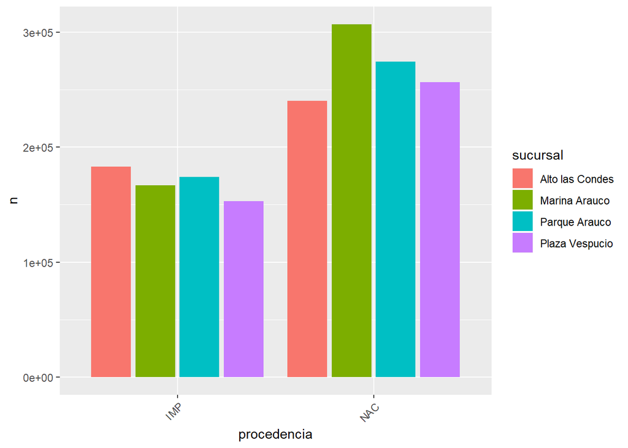

   ```r
   library(tidyverse)

   inventario %>%
     filter(procedencia %in% c("NAC", "IMP")) %>%
     group_by(procedencia,sucursal) %>%
     tally() -> procedencia_n

   procedencia_n %>%
   ggplot() +
     geom_bar(aes(x = procedencia, y = n, fill = sucursal), stat= "identity",
          position=position_dodge2()) +
     theme(axis.text.x = element_text(angle = 45, hjust = 1))
   ```

2. El siguiente código realiza lo pedido:

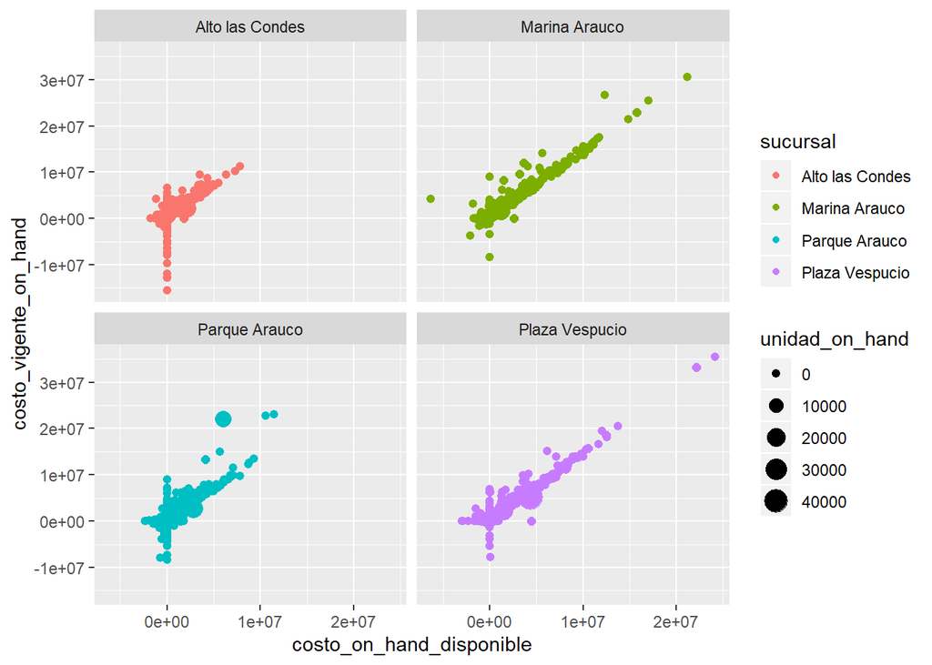

   ```r
   inventario %>%
     ggplot() +
     geom_point(aes(x = costo_on_hand_disponible, y = costo_vigente_on_hand,
                    color = sucursal, size = unidad_on_hand)) +
     facet_wrap(vars(sucursal))
   ```